# Open Case Studies: Exploring CO2 emissions across time

Specifically, we will use the `geom_text_repel()` function from the `ggrepel` package. Just like with `geom_text()`, first we need to specify what data we want to include. Then, we specify with the `aes()` argument that our label will be based on the `Country` variable and we again specify what variable to use for our x axis and y axis, so that we indicate where the labels should be plotted.

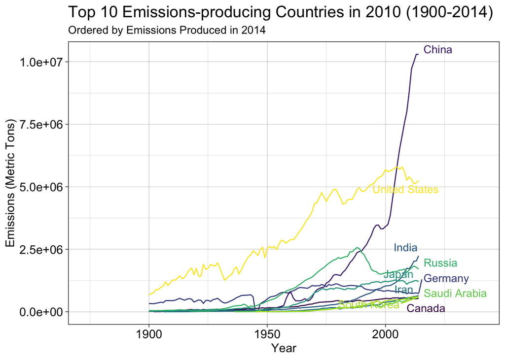

```r
Top10b +
  geom_text_repel(data = data_long %>%
                    filter(Country %in% pull(top_10_count, Country)) %>%
                    filter(Indicator == "Emissions") %>%
                    filter(Year == last(Year)),
                  aes(label = Country, x = Year, y = Value)) +
  theme(legend.position = "none") +
  scale_x_continuous(expand = c(0.3, 0))
```

You can see that this package creates segments that connect the label to the line.

There are many arguments to use to style your labels just the way that you want:

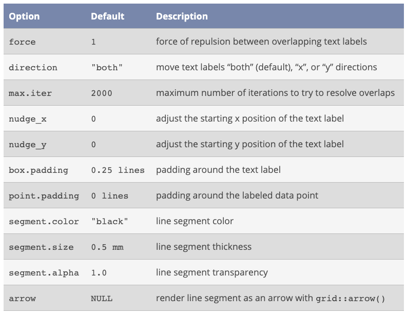

##### [[source]](https://cran.r-project.org/web/packages/ggrepel/vignettes/ggrepel.html)

See [the ggrepel vignette](https://cran.r-project.org/web/packages/ggrepel/vignettes/ggrepel.html) for more details.

Let’s play around with some of these options in the table above.

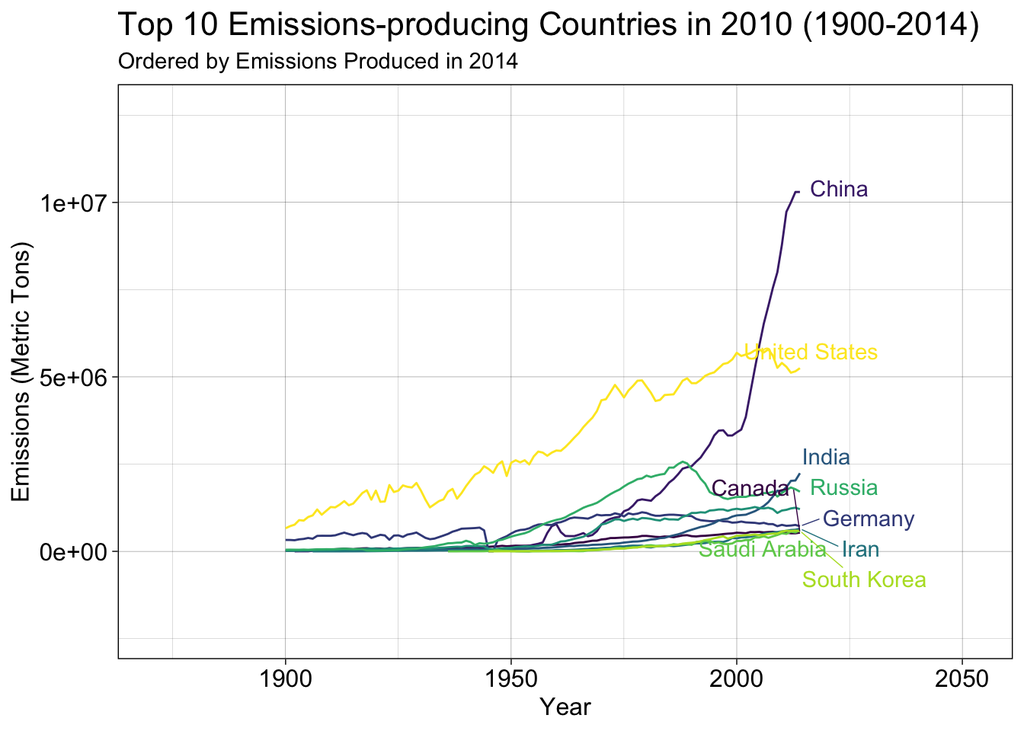

```r
Top10b +
  geom_text_repel(data = data_long %>%
                    filter(Country %in% pull(top_10_count, Country)) %>%
                    filter(Indicator == "Emissions") %>%
                    filter(Year == last(Year)),
                  aes(label = Country, x = Year, y = Value),
                  nudge_x = 10,
                  hjust = 1,
                  vjust = 1,
                  segment.size = 0.25,
                  force = 1) +
  theme(legend.position = "none") +
  scale_x_continuous(expand = c(0.3, 0)) +
  scale_y_continuous(expand = c(0.3, 0))
```

Nice, that looks pretty good. For fun, let’s try showing our data in an entirely different way.

### Tile plots

This time we will create a `geom_tile` plot.

To create this plot we will filter our data to include only the Countries included in the `Country` variable of the `top_10_count`.

Then, we will use the `fct_reorder()` function of the `forcats` package to order our countries based on the last emission value in 2014.

To use this function, the variable that is to be reordered is listed first. The variable that is being used to determine the order is listed second. Finally, a function to apply to the variable listed second is listed third. This function is used to determine the order. In this case, we want to determine the last value of the `Value` variable using the `last()` function (recall that this is also a function of the `dplyr` package). Then, the `Country` variable will be ordered by the last value of the `Value` variable.

To color our plot we will use the `viridis` color palette again but this time we will use the `scale_fill_viridis_c()` – recall that the `_c` indicates a continuous scale. See [the scale_viridis reference](https://ggplot2.tidyverse.org/reference/scale_viridis.html) for more information.

```r
Top10t <-
  data_long %>%
  filter(Country %in% pull(top_10_count, Country)) %>%
  filter(Indicator == "Emissions") %>%
  filter(Year >= 1900) %>%
  ggplot(aes(x = Year, y = fct_reorder(Country, Value, last))) +
    geom_tile(aes(fill = log(Value))) +
    scale_fill_viridis_c()
```

Finally, let’s clean up the axes and the axes labels:

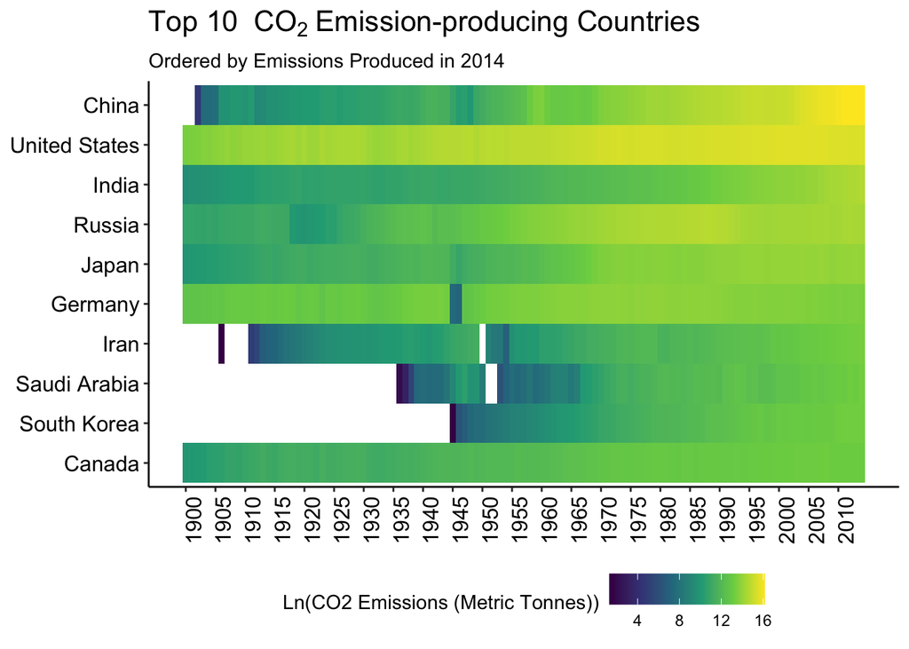

```r
Top10t <- Top10t +
  scale_x_continuous(breaks = seq(1900, 2014, by = 5),
                     labels = seq(1900, 2014, by = 5)) +
  labs(title = "Top 10 " ~CO[2]~ "Emission-producing Countries",
       subtitle = "Ordered by Emissions Produced in 2014",
       fill = "Ln(CO2 Emissions (Metric Tonnes))") +
  theme_classic() +
  theme(axis.text.x = element_text(size = 12, angle = 90, color = "black"),
        axis.text.y = element_text(size = 12, color = "black"),
        axis.title = element_blank(),
        plot.caption = element_text(size = 12),
        plot.title = element_text(size = 16),
        legend.position = "bottom")

Top10t
```

Now let’s say we wanted to save this plot.

We could do so using the using the `save()` function to save this to a “plot” directory in our working directory as an RDA file and we can use the `png()` function to save a png for collaborators. We need to use `dev.off()` function to close the graphical device that we will use to create the png version of the plot so that we are ready to make another plot like this.

```r
save(Top10t, file =here::here("plots", "Top10t.rda"))
png(here::here("plots", "Top10t.png"))
Top10t
dev.off()
```

We see that Germany had very low emission rates at the end of World War II. We also see that the US has consistently had high emission rates since 1900, but the emission rates in China recently surpassed that of the US. The portions of the plot that are white indicate that there is no emission data for that country.

**Question Opportunity**

Think about what the pros and cons are of tile and line plots. In what situations would a tile plot be a better choice for effective scientific communication? In what situations would a line plot be a better choice?

## **More than one variable**

Now, we will visualize all the variables in our dataset.

### Faceted plots

Here, we use the `facet_wrap()` function of the `ggplot2` package, which plots multiple subplots simultaneously.

To use `facet_wrap()` with the option for a different y-axis scale for each subplot, we need to set the `scales` argument equal to `"free_y"`. We can also indicate where we would like the label for the subplots to be located by using the `strip.position` argument.

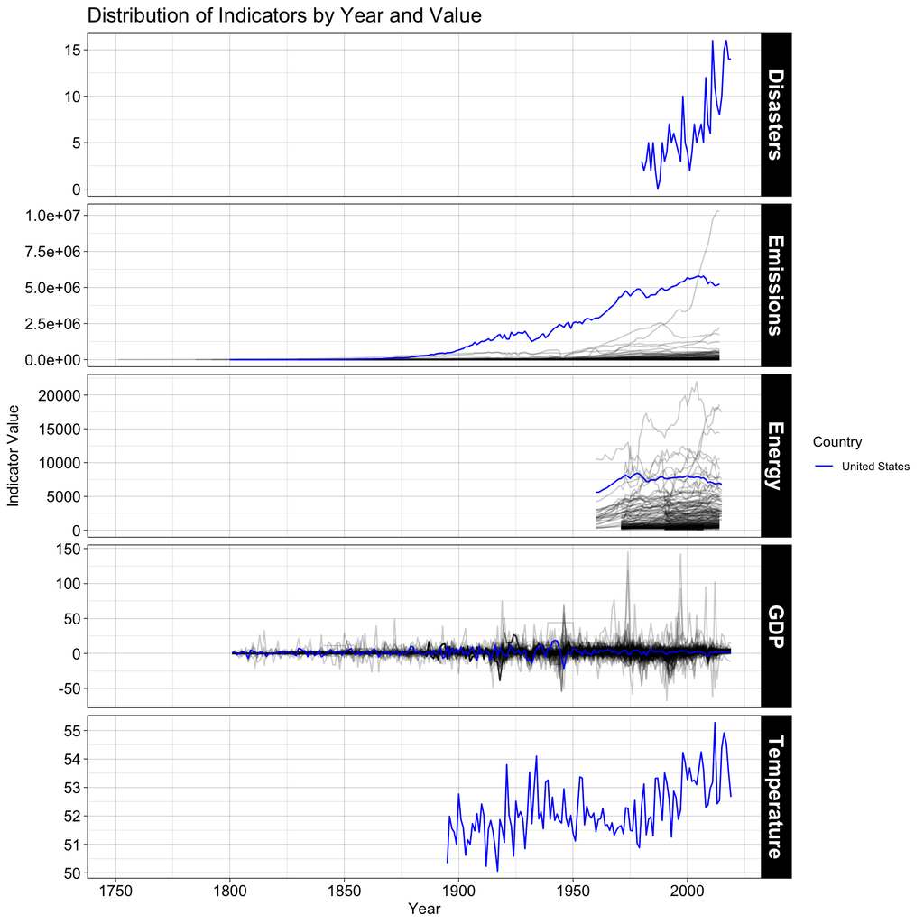

```r
ggplot(data_long, aes(x = Year, y = Value, group = Country)) +
  geom_line(alpha = 0.2) +
  geom_line(data = data_long %>%
              filter(Country == "United States"),
              aes(x = Year, y = Value, color = Country)) +
  scale_colour_manual(values = c("blue")) +
  labs(title = "Distribution of Indicators by Year and Value",
       y = "Indicator Value") +
  my_theme +
  theme(strip.text = element_text(size = 16, face = "bold")) +
  facet_wrap(Indicator ~ .,
             scales = "free_y",
             strip.position = "right",
             ncol = 1)
```

Notice that we can change the size or style of the font for these labels using the `strip.text =` argument of the `theme()` function. We can also specify how many rows or columns we would like the subplots to be shown.

We can also facet by more than one variable (e.g. `Indicator` and `Region` to show the data from the US compared to other countries).

In this case we want the same y-axis to be used across the rows. We will use the `facet_grid()` function this time instead of `facet_wrap()` because of the way that the two facet variables are displayed. The `facet_grid()` function will as you might expect, create an output of plots that are displayed in a grid.

The syntax here is to put the name of the two variables on the left or right side of the `~` symbol, which tells you to facet by rows (left) or columns (right).

First, we will filter out the data about disasters and temperature as this is only for the US, by using the `filter()` function and `!` indicates that we want only values of the `Indicator` variable not in the list containing `"Disasters"` and `"Temperature"`.

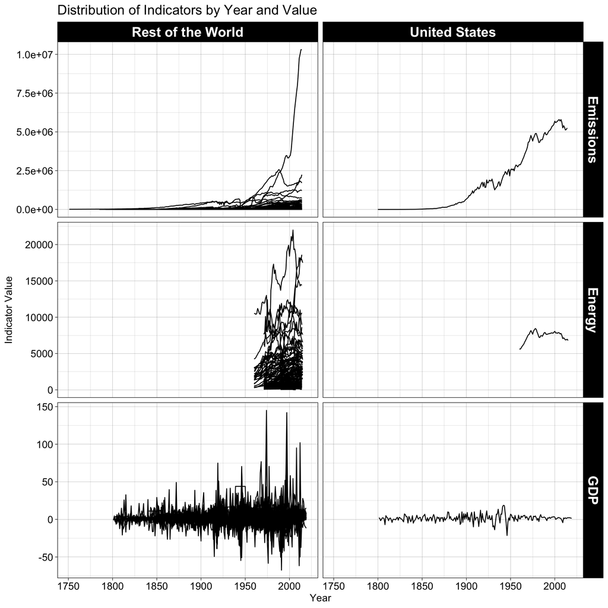

```r
data_long %>%
  filter(!(Indicator %in% c("Disasters", "Temperature"))) %>%
  ggplot(aes(x = Year, y = Value, group = Country)) +
    geom_line() +
    facet_grid(Indicator ~ Region, scales = "free_y") +
    labs(title = "Distribution of Indicators by Year and Value",
         y = "Indicator Value") +
    my_theme +
    theme(strip.text = element_text(size = 16, face = "bold"))
```

From these plots we can see that each type of data spans a different time span.

**Question Opportunity**

What happens when you create the same plot with `facet_wrap()`? Why might this be preferable in certain cases?

**Question Opportunity**

Calculate the total number of countries per year reporting C02 emissions, energy use and GDP. Plot this summary statistic (y-axis) across the years (x-axis). What do you see?

**Hint** : Use the `tally()` function in the `dplyr` package.

### Line segment plots

There are also some other common visualization techniques that are good for showing the difference between a set of observations and a mean value across time.

One of those is a line segment plot. For simplicity, let’s focus only on the data from the US. Let’s calculate the mean across all years for the CO2 emission and temperature from 1980 to 2010. Recall that our `Indicator` variable describes what kind of data we have (Emissions, Temperature, GDP, Energy, Disasters). We will calculate the mean for each `Indicator` set of data by first grouping by this variable and then calculating the mean of the values of the `Value` variable for each set of data. We will call this new variable `Mean`. Then, we calculate the difference between each observation and the mean and create a new variable for these values called `Diff_from_mean`. Again, all of this is performed for each group of data separately. Once we have created the new variables, we want to use the `ungroup()` function so that we no longer perform functions on subsets of the data based on the `Indicator` variable. Finally, we will also create a factor variable about the sign of the `Diff_from_mean` value to distinguish positive or negative changes. We will use this to color our plots.

```r
data_long_us <-
  data_long %>%
  filter(Country == "United States", Year >= 1980, Year <= 2010) %>%
  group_by(Indicator) %>%
  mutate(Mean = mean(Value), Diff_from_mean = Value - Mean) %>%
  ungroup() %>%
  mutate(Diff_color = sign(Diff_from_mean)) %>%
  mutate(Diff_color = as.factor(Diff_color))
```

```r
glimpse(data_long_us)
```

```
Rows: 155
Columns: 9
$ Country        <fct> "United States", "United States", "United States", "Uni…
$ Year           <dbl> 1980, 1981, 1982, 1983, 1984, 1985, 1986, 1987, 1988, 1…
$ Label          <chr> "CO2 Emissions (Metric Tons)", "CO2 Emissions (Metric T…
$ Indicator      <chr> "Emissions", "Emissions", "Emissions", "Emissions", "Em…
$ Value          <dbl> 4720000, 4540000, 4310000, 4340000, 4480000, 4490000, 4…
$ Region         <chr> "United States", "United States", "United States", "Uni…
$ Mean           <dbl> 5134194, 5134194, 5134194, 5134194, 5134194, 5134194, 5…
$ Diff_from_mean <dbl> -414193.548, -594193.548, -824193.548, -794193.548, -65…
$ Diff_color     <fct> -1, -1, -1, -1, -1, -1, -1, -1, -1, -1, -1, -1, -1, -1,…
```

Next, we use the `geom_segment()` function to draw a straight line between points (`x`, `y`) and (`xend`, `yend`). In our case, this creates a plot that shows a bar for the difference between the observation and the mean across all the years.

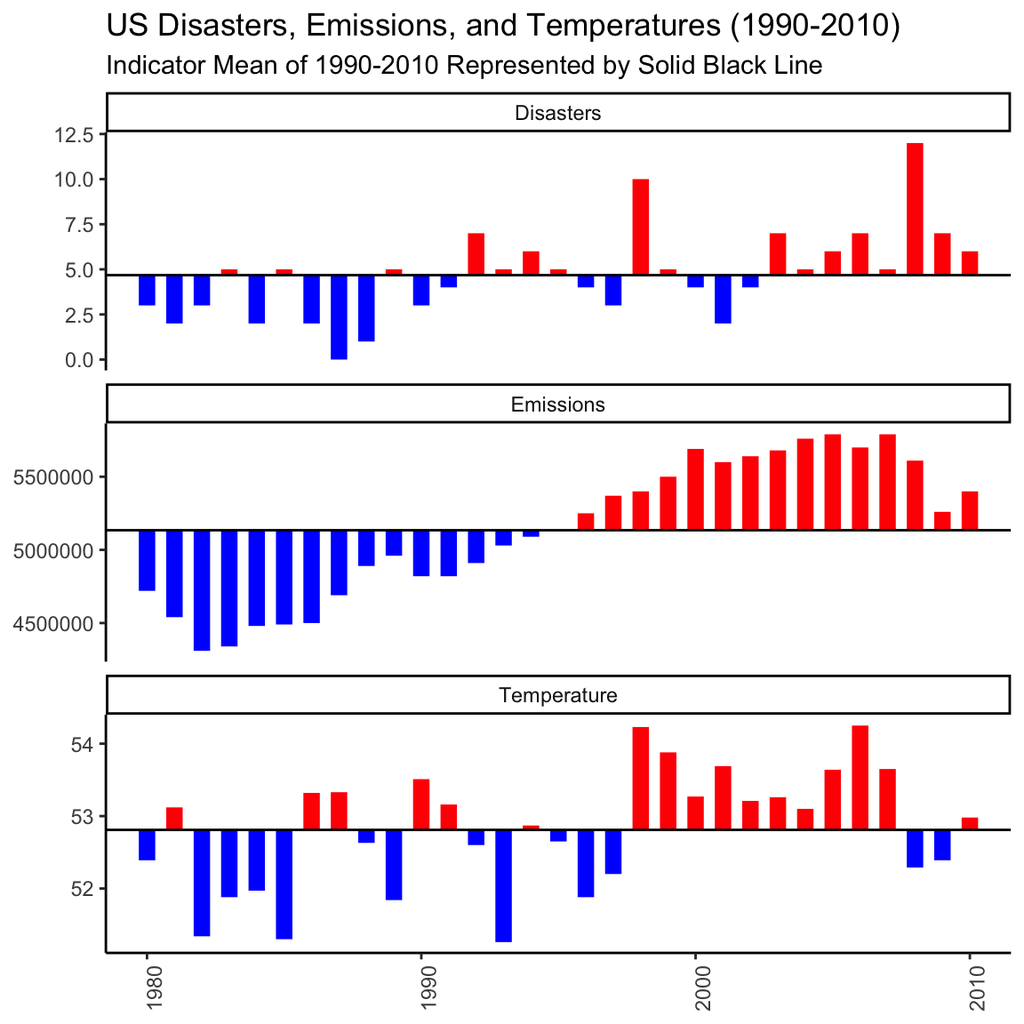

```r
data_long_us %>%
  filter(Indicator %in% c("Emissions", "Temperature", "Disasters")) %>%
  ggplot(aes(x = Year, y = Value)) +
    geom_segment(aes(x = Year, y = Value, xend = Year,
                     yend = Mean, color = Diff_color),
                 size = 3.25) +
  scale_color_manual(values = c("blue", "red")) +
  geom_hline(aes(yintercept = Mean), linetype = 1, color = "black") +
  facet_wrap(Indicator ~ ., scales = "free_y", ncol = 1) +
  theme_classic() +
  theme(axis.text.x = element_text(angle = 90),
         axis.title = element_blank(),
    legend.position = "none")  +
  labs(title = "US Disasters, Emissions, and Temperatures (1990-2010)",
    subtitle = "Indicator Mean of 1990-2010 Represented by Solid Black Line")
```

We can see from this plot that overall there has been an increase in disasters, emissions and temperature in the most recent years.

**Question Opportunity**

What trends do you see in GDP and energy use across time?

### Scatter plots

Next, let’s zoom in on two of the variables: CO2 emissions and temperature. We use years between 1980 and 2014 as we have values for all of those years for these two variables.

We know that the datasets do not span the same amount of time. So let’s limit this plot to only the years where the data overlaps for both CO2 emissions and temperature.

We use the `geom_point()` function to create a scatter plot between the `x` and `y` variable defined in `aes()` where `x` is time and `y` is one of the two variables. We also add a line on top of the scatter plot that smooths the trend from the points. The smoother we used here is `loess` [locally estimated scatterplot smoothing](https://en.wikipedia.org/wiki/Local_regression), a type of [local polynomial regression](https://en.wikipedia.org/wiki/Local_regression) fitting. This is a nonparametric regression that is also called a “moving regression” where subsets of points that are close to one another (hence the term local) are used in a least squares linear or nonlinear fit. Thus this results in a fit that may curve with the data.

```r
CO2_temp_US_facet <-
  data_long %>%
  filter(Country == "United States", Year >= 1980, Year <= 2014,
         Indicator %in% c("Emissions", "Temperature")) %>%
  ggplot(aes(x = Year, y = Value)) +
  geom_point() +
  geom_smooth(method = "loess", se = FALSE) +
  scale_x_continuous(breaks = seq(1980, 2014, by = 5),
                     labels = seq(1980, 2014, by = 5)) +
  facet_wrap(Label ~ ., scales = "free_y", ncol = 1) +
  theme_classic() +
  theme(axis.text.x = element_text(size = 12, angle = 90, color = "black"),
        axis.text.y = element_text(size = 12, color = "black"),
        strip.text.x = element_text(size = 14),
         axis.title = element_blank(),
         plot.title = element_text(size = 16))
  labs(title = "US Emissions and Temperatures (1980-2014)")
```

```
$title
[1] "US Emissions and Temperatures (1980-2014)"

attr(,"class")
[1] "labels"
```

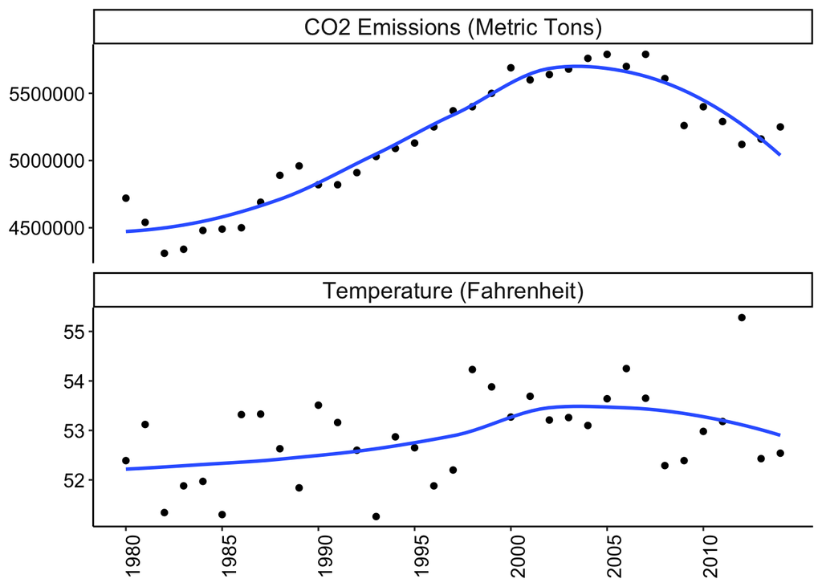

```r
CO2_temp_US_facet
```

Note, we are showing a different `theme` here, namely the `theme_classic()` theme. We can see that there are similar patterns of CO2 emission levels and average annual temperatures.

We will save this plot now like so to our “plots” directory:

```r
save(CO2_temp_US_facet, file =here::here("plots", "CO2_temp_US_facet.rda"))
png(here::here("plots", "CO2_temp_US_facet.png"))
CO2_temp_US_facet
dev.off()
```

**Question Opportunity**

- Try show a similar plot without filtering by years and faceting by the other three variables: energy use, GDP and disasters. Are there other variables that look like they might have a similar pattern to CO2 emissions?
- Try using a different smoother in `geom_smooth()`.

Next, instead of looking at the variables separately in faceted plots, let’s look at the relationship between CO2 emissions and other variables directly. Thus, it is useful to have each of these indicators as their own variable.

We can do this by using `pivot_wider()` to transform our long data table into a wide format.

```r
wide_US <-
  data_long %>%
  filter(Country == "United States", Year >= 1980, Year <= 2014) %>%
  select(-Label) %>%
  pivot_wider(names_from = Indicator, values_from = Value)
```

Let’s save this data as an rda file for future use and as a csv file, as this is often useful for collaborators. We will save this in a “wrangled” subdirectory of our “data” directory of our working directory.

```r
save(wide_US, file = here::here("data", "wrangled", "wrangled_US_data.rda"))
readr::write_csv(wide_US, path = here::here("data", "wrangled", "wrangled_US_data.csv"))
```

Now we can specify which indicators we want to look at, so now we can specifically look at emissions and temperature.

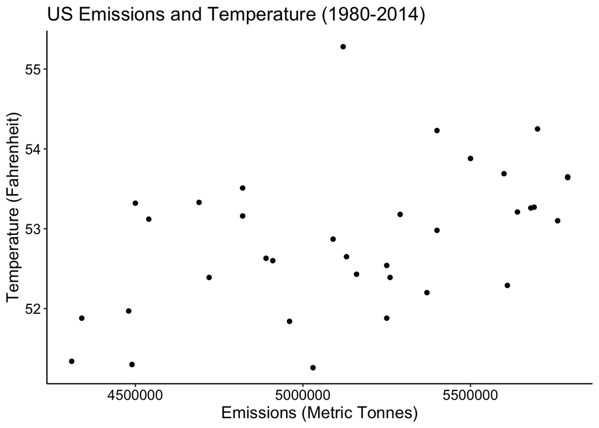

```r
CO2_temp_US <-
  wide_US %>%
  ggplot(aes(x = Emissions, y = Temperature)) +
    geom_point() +
    theme_classic() +
    theme(axis.text.x = element_text(size = 12, color = "black"),
          axis.text.y = element_text(size = 12, color = "black"),
           axis.title = element_text(size = 14),
           plot.title = element_text(size = 16)) +
    labs(title = "US Emissions and Temperature (1980-2014)",
         x = "Emissions (Metric Tonnes)",
         y = "Temperature (Fahrenheit)")


CO2_temp_US
```

It might be helpful to add a trend line to this. We can do so by using the `geom_smooth()` function of the `ggplot2` package.

If we want to look at a linear trend we need to specify the method using the `method = lm` argument. This adds a line to the data based on a linear model of the data using the `lm` function of the `stats` package. We will discuss the se = FALSE argument later.

We can just add this to the plot object that we just created to create a plot with this trend line.

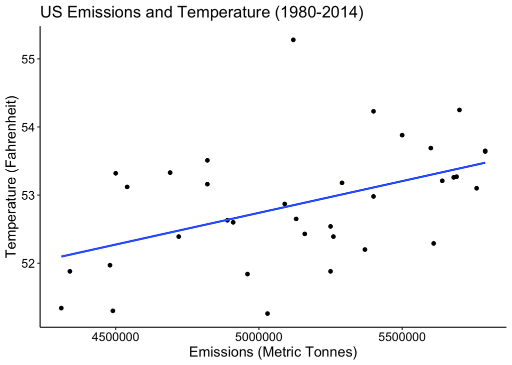

```r
CO2_temp_US <- CO2_temp_US + geom_smooth(method = "lm", se = FALSE)
CO2_temp_US
```

Indeed, it does look like there is a positive, linear trend.

We will also save this plot:

```r
save(CO2_temp_US, file =here::here("plots", "CO2_temp_US.rda"))
png(here::here("plots", "CO2_temp_US.png"))
CO2_temp_US
dev.off()
```

**Question Opportunity**

- Make similar plots for between CO2 emissions and other variables.
- Are there other pairs variables that look like they might have a similar pattern to CO2 emissions?
- Does this match what we saw above?
- Do these trend look linear or non-linear?

Now that we see that there might be a linear relationship between CO2 emissions and temperature, let’s learn about some statistical techniques to measure the strength of that relationship.

# **Data Analysis**

If you are following along and stopped you could load the data you will need like so:

```r
load(here::here("data", "wrangled", "wrangled_US_data.rda"))
```

**If you skipped the previous sections click here.**

First you need to install and load the `OCSdata` package:

```r
# install.packages("OCSdata")
# You will need to install the package if you haven't already done so.
library(OCSdata)
```

Then, you may load the wrangled data using the following code:

```r
wrangled_rda("ocs-bp-co2-emissions", outpath = getwd())
load(here::here("OCSdata", "data", "wrangled", "wrangled_US_data.rda"))
```

If the package does not work for you, alternatively, an RDA file (stands for R data) of the data (called `wrangled_US_data.rda`) can be found [here](https://github.com//opencasestudies/ocs-bp-co2-emissions/tree/master/data/wrangled) or slightly more directly [here](https://raw.githubusercontent.com/opencasestudies/ocs-bp-co2-emissions/master/data/wrangled/wrangled_US_data.rda). Download this file and then place it in your current working directory within a subdirectory called “wrangled” within a subdirectory called “data” to copy and paste our code. We used an RStudio project and the [`here` package](https://github.com/jennybc/here_here) to navigate to the file more easily.

```r
load(here::here("data", "wrangled", "wrangled_US_data.rda"))
```

**Click here to see more about creating new projects in RStudio.**

See [here](https://support.rstudio.com/hc/en-us/articles/200526207-Using-Projects) to learn more about using RStudio projects and here to learn more about the `here` package.

In this section, we are going to introduce some ways to better understand how two variables move together. We will focus on the CO2 emissions and temperature, but you will be encouraged to explore the relationship between CO2 emissions and the other variables.

### **Basic summary statistics**

We can always calculate the sample mean and variance for two variables.

```r
wide_US %>%
  summarize(mean(Emissions), mean(Temperature), sd(Emissions), sd(Temperature))
```

```
# A tibble: 1 × 4
  `mean(Emissions)` `mean(Temperature)` `sd(Emissions)` `sd(Temperature)`
              <dbl>               <dbl>           <dbl>             <dbl>
1          5142286.                52.9         450549.             0.891
```

These are useful, but on their own they do not summarize whether or not there is a relationship between `Emissions` and `Temperature` (also these are on different scales entirely).

What else could we use? Next, we are going to learn about the correlation coefficient, which is a summary statistic that describes how two variables are related or move together.

### **Correlation coefficient**

We can use the [correlation coefficient](https://rafalab.github.io/dsbook/regression.html#corr-coefl). Here, we are using this summary statistic to measure the strength of a *linear* relationship between two variables.

If we plot one variable on the x-axis and the other variable on the y-axis, we can see:

1. The strength of the relationship - based on how well the points form a line
2. The direction of the relationship - based on if the points progress upward or downward

If the variables point upward in a very clear line, then there is a strong positive relationship. If the points do not really form a line, then there is a weak linear relationship or no linear relationship. There may however be a nonlinear relationship if the points create a different but defined shape.

See [here](https://towardsdatascience.com/estimating-non-linear-correlation-in-r-62c6571cb1db) for more information on nonlinear relationships.

If the points form a downward sloping line, then there is a negative relationship.

[figure not shown]

##### [[source]](https://www.mathsisfun.com/data/correlation.html)

The numbers below each plot above are called correlation coefficients. They range from -1 to 1. A value of zero indicates that there is no correlation between the variables. While a value of 1 or -1 indicates perfect correlation, the closer the coefficient is to 1 or -1, the stronger the relationship. The sign of the coefficient indicates the direction of the relationship. If there is a negative relationship then the variables show opposing changes from each other - as one gets larger the other gets smaller. If the sign is positive, then the variables increase similarly.

We previously made this plot:

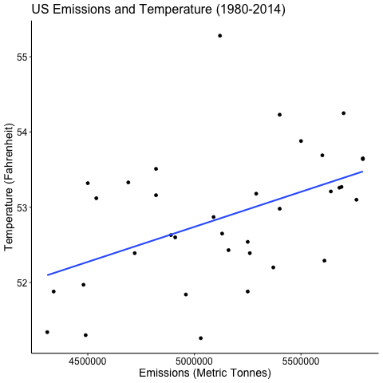

Let’s calculate the Pearson’s correlation coefficient called “Rho” $\rho$ between CO2 emissions and temperature in the US. There are a few ways to calculate a correlation coefficient and this is one of the most common.

Formally, if we have a pair of observations $(x_1, y_1), \dots, (x_n,y_n)$, the correlation coefficient $\rho$ between $x$ and $y$ is defined as

$$\rho = \frac{1}{n-1} \sum_{i=1}^n \left( \frac{x_i-\mu_x}{\sigma_x}
\right)\left( \frac{y_i-\mu_y}{\sigma_y} \right)$$
where $\mu_x, \mu_y$ are the means of $x_1,\dots, x_n$ and $y_1, \dots, y_n$, respectively, and $\sigma_x, \sigma_y$ are the standard deviations.

Therefore, we can standardize the two variables and essentially average (the denominator is n-1) the standardized values to calculate the correlation coefficient `rho`.

Here we will manually perform the calculation. We will use the `tally()` function of the `dplyr` package to get the number of samples $n$. In this case this is equivalent to the number of rows in the `wide_US` tibble. We need to then use the `pull()` function to specifically grab the value out of the tibble that is created from using this function. As you can see from using the base `class()` function that this is a `tbl_df` which is short for tibble data frame (the tidyverse version of a data frame) rather than just a number.

```r
tally(wide_US)
```

```
# A tibble: 1 × 1
      n
  <int>
1    35
```

```r
class(tally(wide_US))
```

```
[1] "tbl_df"     "tbl"        "data.frame"
```

When we check the class after using the `pull()` function we see that it is an integer.

```r
pull(tally(wide_US), n)
```

```
[1] 35
```

```r
class(pull(tally(wide_US), n))
```

```
[1] "integer"
```

We will also use the base `scale()` function to standardize the `Emissions` and `Temperature` values.

```r
wide_US %>%
  summarize(rho = (1/(pull(tally(wide_US), n) -1)) *(sum(scale(Emissions) * scale(Temperature)))) %>%
  pull(rho)
```

```
[1] 0.4711717
```

Alternatively, you can use the `cor()` function in base R like so:

```r
wide_US %>%
  summarize(r = cor(x = Emissions,
                    y = Temperature,
               method = "pearson")) %>%
  pull(r)
```

```
[1] 0.4711717
```

If you want to learn more about why this is the calculation to determine the strength of the relationship between two variables, see this [link](https://bcheggeseth.github.io/Stat155Notes/two-quantitative-variables.html).

**Question Opportunity**

There are different types of correlation coefficients. Look at the help file for the `cor()` function by typing `?cor()` into the RStudio Console to learn more and then try a different `method`.

What are the differences?

**Question Opportunity**

- Try calculating the correlation coefficient between CO2 emissions and the other variables.
- What do you expect?

To test if the association between a pair of variables is [statistically significant](https://en.wikipedia.org/wiki/Statistical_significance), you can use the `cor.test()` of the `stats` package to calculate the correlation coefficient, as well as confidence intervals for correlation coefficients.

We can use the `tidy()` function of the `broom` package to make the output more usable for working with in R. The role of this function is to pull numeric values from outputs and create a data frame of the values.

```r
cor.test(pull(wide_US, Emissions),
         pull(wide_US, Temperature))
```

```
    Pearson's product-moment correlation

data:  pull(wide_US, Emissions) and pull(wide_US, Temperature)
t = 3.0686, df = 33, p-value = 0.004277
alternative hypothesis: true correlation is not equal to 0
95 percent confidence interval:
 0.1636155 0.6952523
sample estimates:
      cor
0.4711717
```

```r
broom::tidy(cor.test(pull(wide_US, Emissions),
         pull(wide_US, Temperature)))
```

```
# A tibble: 1 × 8
  estimate statistic p.value parameter conf.low conf.high method     alternative
     <dbl>     <dbl>   <dbl>     <int>    <dbl>     <dbl> <chr>      <chr>
1    0.471      3.07 0.00428        33    0.164     0.695 Pearson's… two.sided
```

We see that the correlation coefficient quantifying the strength of the linear relationship between C02 emissions and temperature is statistically significant.

### **Relationship between correlation and linear regression**

Let’s briefly discuss the relationship between correlation and linear regression, which is further described in the [Introduction to Data Science book](https://rafalab.github.io/dsbook/regression.html).

We can use a regression line to predict a random variable $Y$ given that we have gathered or observed some data about another variable $X=x$. The regression line formally is defined as:

$$\left( \frac{Y-\mu_Y}{\sigma_Y} \right)
= \rho \left( \frac{x-\mu_X}{\sigma_X} \right)$$
where $\mu_X$ and $\sigma_X$ ($\mu_Y$ and $\sigma_Y$) are the mean and standard deviation of $X$ ($Y$), and $\rho$ is correlation between $X$ and $Y$. If $x$ is larger than $\mu_X$, then for every $\sigma_X$, then $Y$ will also increase $\rho$ standard deviations above $\mu_Y$.

Re-organizing the terms so that $Y$ is on the left side and everything else is on the right side, we get:

$$Y = \mu_Y + \rho \left(
\frac{x-\mu_X}{\sigma_X} \right) \sigma_Y$$
Thinking about some extreme examples:

- If $\rho$ = 0 (i.e. no correlation), we ignore the $x$ term entirely and only predict $Y$ using the mean $\mu_Y$.
- If $\rho$ = 1 (or -1) (i.e. perfect correlation), the regression line predicts an increase (or decrease) that is the same number of SDs.
- If $\rho$ is between -1 and 1, then we predict using both terms on the right hand side.

To add regression lines to plots, we will need the above formula in the form:

$$y= b + mx \mbox{ with slope } m = \rho \frac{\sigma_y}{\sigma_x} \mbox{
and intercept } b=\mu_y - m \mu_x$$

In our example, we can calculate the slope and intercept using the formula above and plot the line.

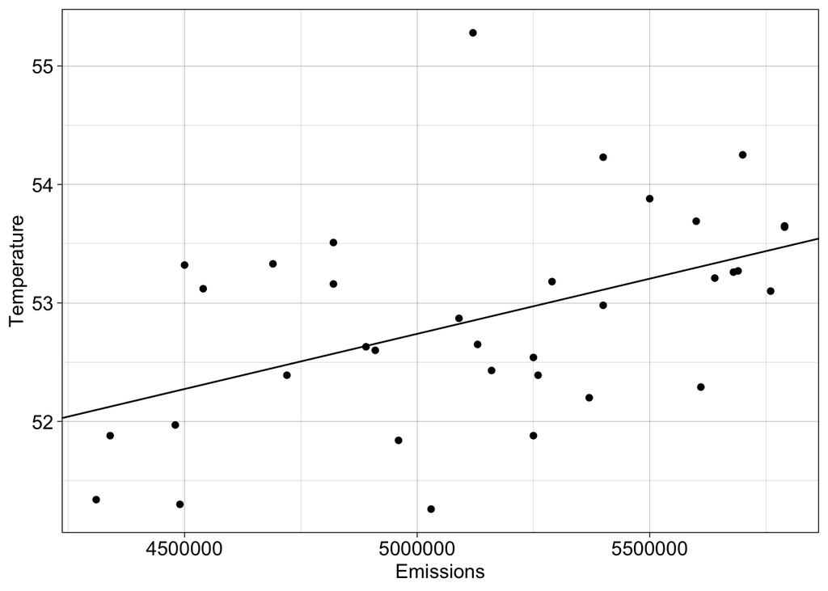

```r
wide_US_summary <-
  wide_US %>%
  summarize(mu_x = mean(Emissions), sd_x = sd(Emissions),
            mu_y = mean(Temperature), sd_y = sd(Temperature),
            rho = cor(Emissions, Temperature),
            slope = rho * sd_y / sd_x,
            intercept = mu_y - rho * sd_y / sd_x * mu_x)

wide_US %>%
  ggplot(aes(x = Emissions, y = Temperature)) +
    geom_point() +
    geom_abline(slope = wide_US_summary$slope,
                intercept = wide_US_summary$intercept) +
  theme_linedraw() +
  theme(axis.text.x = element_text(size = 12),
        axis.text.y = element_text(size = 12),
       axis.title.x = element_text(size = 12),
       axis.title.y = element_text(size = 12),
       plot.caption = element_text(size = 12),
         plot.title = element_text(size = 16))
```

**Note**: In the plot above, we use the scale of the original variables (CO2 emission and temperature), but the formula above implies that standardization of the variables (i.e. subtracting the mean and dividing by the standard deviation) allows the regression line to have an intercept of 0 and slope equal to $\rho$. A similar plot in standardized units is given below.

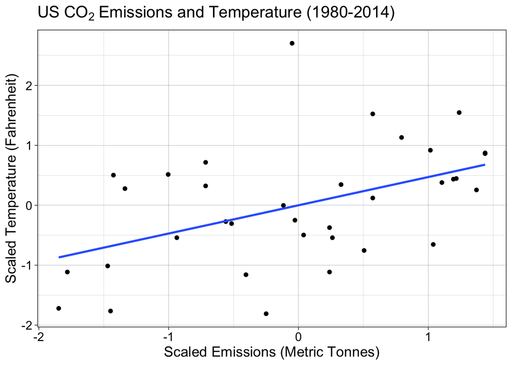

```r
CO2_temp_US_scaled<-wide_US %>%
  ggplot(aes(x = scale(Emissions), y = scale(Temperature))) +
    geom_point() +
    geom_smooth(method = "lm", se = FALSE) +
  labs(title = "US" ~ CO[2]~ "Emissions and Temperature (1980-2014)",
         y = "Scaled Temperature (Fahrenheit)",
         x = "Scaled Emissions (Metric Tonnes)") +
  theme_linedraw() +
  theme(axis.text.x = element_text(size = 12),
        axis.text.y = element_text(size = 12),
       axis.title.x = element_text(size = 14),
       axis.title.y = element_text(size = 14),
       plot.caption = element_text(size = 12),
         plot.title = element_text(size = 16))

CO2_temp_US_scaled
```

Notice that we also use the `geom_smooth(method = "lm")` function that we previously used. Again, this adds a line corresponding to the slope and intercept from the `lm()` function from the `stats` R package.

**Question Opportunity**

What does `se = FALSE` mean? Try turning it to TRUE. What happens?

**Click here for the answer.**

`se` stands for standard error. The gray shading shows the [confidence interval](https://stattrek.com/regression/slope-confidence-interval.aspx) of the smooth line.

### **Limitations of Correlation**

While correlation is useful in many settings to understand how two variables move together, correlation is not always a useful summary. For example, here are ways it might not be useful:

- A linear relationship might not be the best way to capture the relationship.
- If an individual were interested in understanding a *causal* relationship between two variables, as [correlation does not imply causation](https://dfrieds.com/math/correlation-does-not-imply-causation.html). Another way of stating this is that simply showing there is a linear trend over time does not imply there is a causal relationship between these two variables.

As you can see from this plot, often data may show a similar pattern over time by random chance. See this [website](https://www.tylervigen.com/spurious-correlations) for more examples.

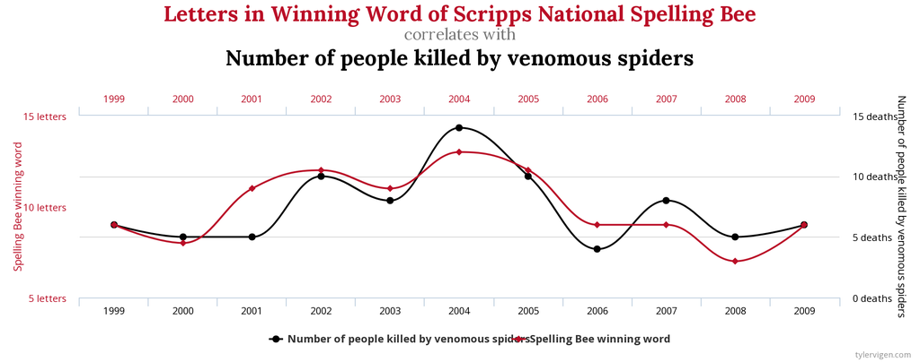

##### [[source]](http://tylervigen.com/spurious-correlations)

In this example and in our case study, data was collected over time. This type of data will often have what is called [autocorrleation](https://en.wikipedia.org/wiki/Autocorrelation) or serial correlation. This means that data points from one year to the next may be similar to one another or have some sort of internal structure related to time (such as seasonality). Let’s think about our CO2 emission and temperature data. You may be able to see how one year of CO2 emissions might be fairly similar to next year, because the number of sources (such as industrial factories and cars) in the US will change slightly from year to year, but they will be related to that of the previous years. Anytime we look at correlation between two variables that each have autocorrelation, this can result in a higher likelihood of correlation between these variables.

Indeed if we look at correlation between two random variables with autocorrelation we can see an inflation in the correlation rho values between the two variables, as compared to that of variables that do not have autocorrelation.

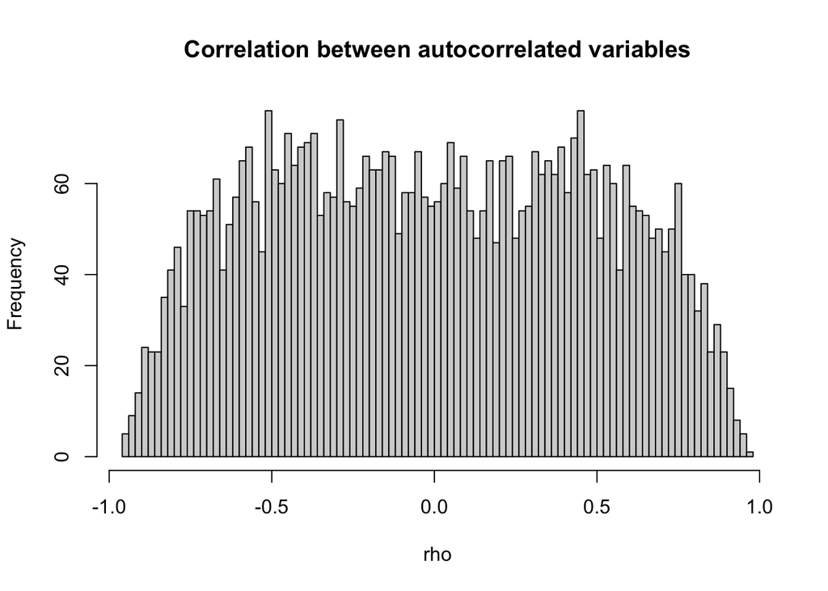

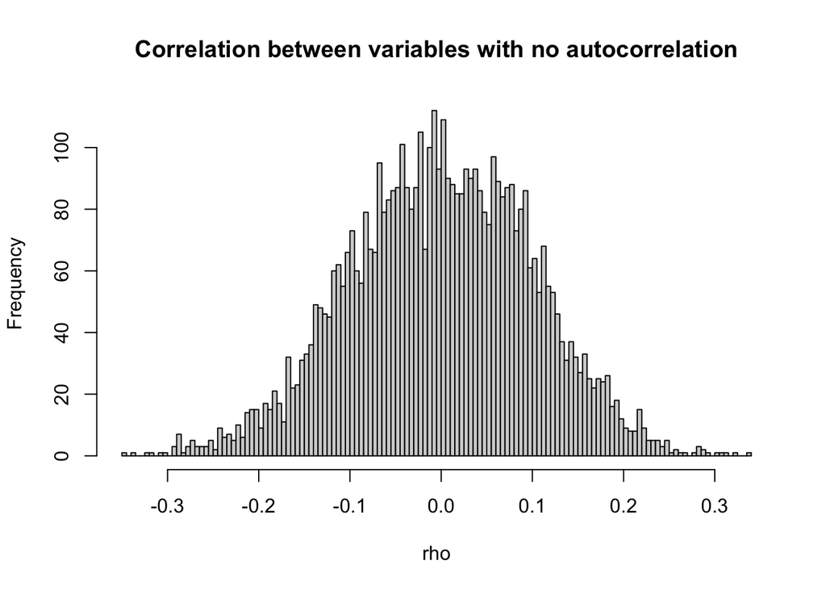

This is something to keep in mind when you evaluate how two things are related to one another over time. There are [methods](https://online.stat.psu.edu/stat462/node/188/) that have been developed to account for this in [time series](https://en.wikipedia.org/wiki/Time_series) analysis (analyzing data over time). This does not mean that two variables (such as CO2 and temperature) may not be in fact correlated, it just means that we need to account for the autocorrelation within each variable, however this is beyond the scope of this case study.

# **Summary**

## **Summary Plot**

We will also save the figure using the `grDevices` `png()` function. We can specify the name of our plot file and where we want it to be saved using the `here()` function of the `here` package. In this case in the `img` subdirectory of the directory containing our .Rproj file. We can also specify the size of the plot and the resolution using the `res` argument. The `grDevices` `dev.off()` function is necessary to close the graphics device.

This will include a few plots that we made previously in other sections. We saved these in the “plots” directory and will load these now for users who stopped and restarted or started at the data analysis section.

```r
load(here::here("plots", "CO2_world.rda"))
load(here::here("plots", "Top10t.rda"))
load(here::here("plots", "CO2_temp_US_facet.rda"))
```

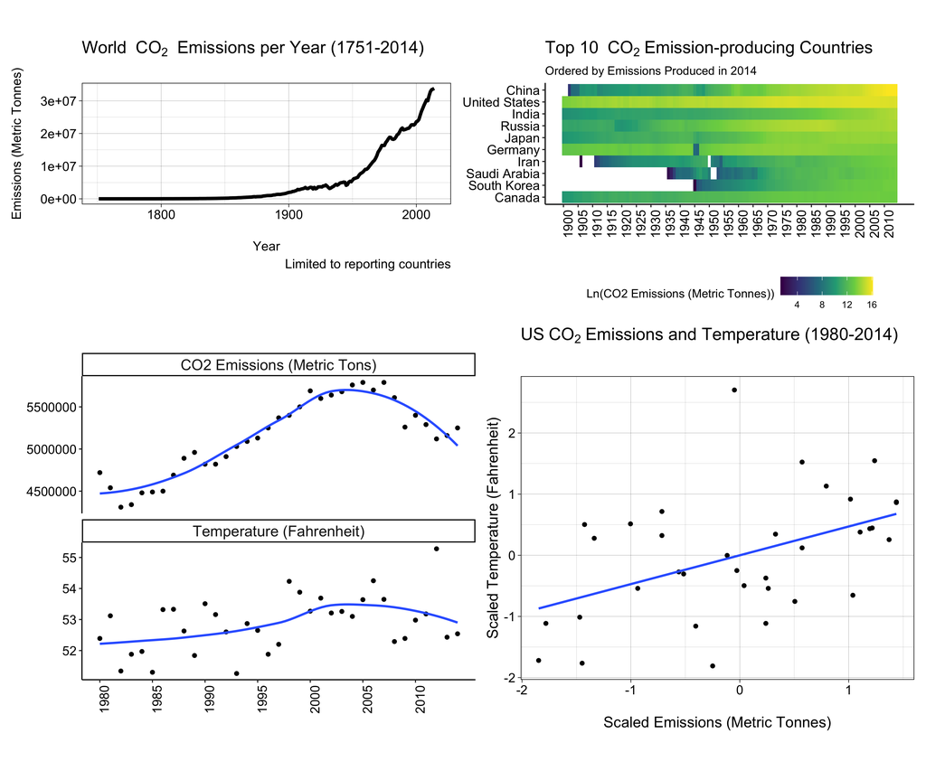

```r
png(here::here("img", "mainplot.png"), units = "in", width = 12, height = 10, res = 300)
(CO2_world | Top10t) / (CO2_temp_US_facet | CO2_temp_US_scaled) +
  plot_layout(widths = c(1, 2),
              heights = unit(c(4, 10), c('cm', 'cm')))
dev.off()
```

## **Synopsis**

In this case study we evaluated CO2 emissions from as far back as 1751 for some countries to 2014. We discovered that global levels of CO2 emissions have dramatically increased over time. We also learned that some countries have been responsible for particularly high levels.

We also took a look at how CO2 emissions might relate to other factors, such as temperature, energy use, and natural disasters. We learned that we can summarize the relationship between two sets of data using **correlation coefficients**. We also learned that we can use **regression** to predict or describe how changes in one variable may influence changes in another variable. Importantly, we also learned that just because two variables show strong correlation or show an association, it does not necessarily indicate that they are causally related.

However, there is quite a bit of scientific evidence to indicate that in fact CO2 emissions trap heat and lead to increased global temperatures. Yet, it is important to realize that there are other factors involved in the relationship between US CO2 emissions and US annual average temperatures. For example there are CO2 emissions from other countries in the atmosphere, there are other greenhouse gases, there is already existing CO2 in the atmosphere that will continue to trap heat for many years, and finally there is heat trapped in the ocean due to previous emissions that will cause delayed changes in surface temperatures. However, it is vital that we work around the globe to reduce future greenhouse gas emissions to mitigate the increased temperatures that we will experience due to previous and existing CO2 emissions, so that the warming temperatures aren’t as extreme as they could be. Furthermore, we need to prepare for increased rates of natural disasters and how these may influence people around the world. Evidence suggests that impoverished people are the [most affected by disasters](https://ourworldindata.org/natural-disasters). We need to be particularly mindful of this as we prepare for the future.

# **Suggested Homework**

Ask students to create a plot with labels showing the countries with the lowest CO2 emission levels.

Ask students to plot CO2 emissions and other variables (e.g. energy use) on a scatter plot, calculate the Pearson’s correlation coefficient, and discuss results.

# **Additional information**

## **Helpful Links**

[Tidyverse](https://www.tidyverse.org/)  
[RStudio cheatsheets](https://rstudio.com/resources/cheatsheets/) [Introduction to correlation](https://www.mathsisfun.com/data/correlation.html) [Correlation coefficient](https://rafalab.github.io/dsbook/regression.html#corr-coefl)  
[Correlation does not imply causation](https://dfrieds.com/math/correlation-does-not-imply-causation.html)  
[Regression](https://rafalab.github.io/dsbook/regression.html)  
[Locally estimated scatterplot smoothing](https://en.wikipedia.org/wiki/Local_regression)  
[Local polynomial regression](https://en.wikipedia.org/wiki/Local_regression)  
[Autocorrleation](https://en.wikipedia.org/wiki/Autocorrelation)  
[Time series](https://en.wikipedia.org/wiki/Time_series)  
[Methods to account for autocorrelation](https://online.stat.psu.edu/stat462/node/188/)  
[US Environmental Protection Agency (EPA) Inventory of U.S. Greenhouse Gas Emissions and Sinks 2020 Report](https://www.epa.gov/sites/production/files/2020-04/documents/us-ghg-inventory-2020-main-text.pdf)  
[National Climate Assessment Report](https://data.globalchange.gov/report/nca3-overview)  
[Greenhouse gases](https://www.epa.gov/report-environment/greenhouse-gases) [Climate change](https://world101.cfr.org/global-era-issues/climate-change/climate-change-adaptations)

**Packages used in this case study:**

| Package | Use in this case study |
| --- | --- |
| [`here`](https://github.com/jennybc/here_here) | to easily load and save data |
| [`readxl`](https://readxl.tidyverse.org/) | to import the excel file data |
| [`readr`](https://readr.tidyverse.org/) | to import the csv file data |
| [`dplyr`](https://dplyr.tidyverse.org/) | o view and wrangle the data, by modifying variables, renaming variables, selecting variables, creating variables, and arranging values within a variable |
| [`magrittr`](https://cran.r-project.org/web/packages/magrittr/vignettes/magrittr.html) | to use data objects using the `%>%` pipe operator |
| [`stringr`](https://stringr.tidyverse.org/) | to select only the first 4 characters of date data |
| [`purrr`](https://purrr.tidyverse.org/) | to apply a function on a list of tibbles (tibbles are the tidyverse version of a data frame) |
| [`tidyr`](https://tidyr.tidyverse.org/) | to drop rows with `NA` values from a tibble |
| [`forcats`](https://forcats.tidyverse.org/) | to reorder the levels of a factor |
| [`ggplot2`](https://ggplot2.tidyverse.org/) | to make visualizations |
| [`directlabels`](http://directlabels.r-forge.r-project.org/docs/index.html) | to add labels to plots easily |
| [`ggrepel`](https://cran.r-project.org/web/packages/ggrepel/vignettes/ggrepel.html) | to add labels that don’t overlap to plots |
| [`broom`](https://www.tidyverse.org/blog/2018/07/broom-0-5-0/) | to make the output form statistical tests easier to work with |
| [`patchwork`](https://github.com/thomasp85/patchwork) | to combine plots |

**Estimate of RMarkdown Compilation Time:**

```
About 12 - 22 seconds
```

This compilation time was measured on a PC machine operating on Windows 10. This range should only be used as an estimate as compilation time will vary with different machines and operating systems.

## **Acknowledgments**

We would like to acknowledge [Megan Latshaw](https://www.jhsph.edu/faculty/directory/profile/1708/megan-weil-latshaw) for assisting in framing the major direction of the case study.

We would like to acknowledge [Qier Meng](https://www.opencasestudies.org/authors/qmeng/) and [Michael Breshock](https://mbreshock.github.io/) for their contributions to this case study.

We would also like to acknowledge the [Bloomberg American Health Initiative](https://americanhealth.jhu.edu/) for funding this work.